# Cerisier noir

Delgrange Lucien

Etudiant à l’université de Mons en BAC2 Biologie

11 décembre 2017

# 1 Introduction

Le cerisier noir : *Prunus serotina* Ehrh. est un arbre de la famille des Rosaceae originaire d’Amerique du Nord.Ayant été introduit en europe au XVII siècle, il est maintenant considéré comme invasif dans le continent. Il peut atteindre jusqu’à 35 m de hauteur mais on le retrouve aussi sous forme d’arbuste ou de petit arbre.

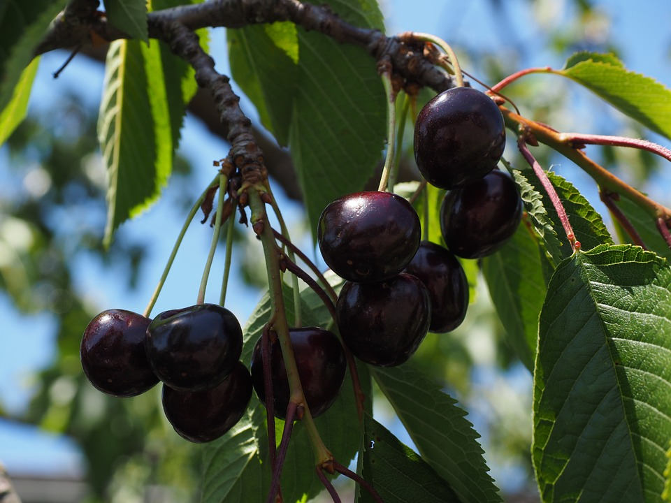

# But

## 1.1 Acquisition des données

Le jeu de donnée provient de * The Minitab Student Handbook. Duxbury Press" de Ryan, T. A., Joiner, B. L. and Ryan, B. F. (1976)*.

# 2 Matériels et méthodes

## 2.1 Analyse des données

Un modèle de régression linéaire sera utilisé pour établir une relation linéaire entre 2 variables quantitatives. Le test ne traite pas ces 2 variables de manière égale : une des deux variables est dite dépendante de l’autre ( indépendante ).

on utilise comme critère de détermination de la droite : la minimisation de la somme des carrés des résidus.

- Nous testons l’homoscedasticité avec les graphiques suivants :

Le Graphique des résidus en fonction des valeurs ajustées.

Le Graphique de la racine carrée des résidus standardisés en fonction des valeurs ajustées.

- Nous testons graphiquement la pertinence de la distribution des résidus standardisés avec la distribution normale.